# Makroekonometrija_1UZD

```r
suppressPackageStartupMessages({
    suppressWarnings({
        library(ggplot2)
        library(dplyr)
        library(plm)
        library(stargazer)
    })
})
```

```r
# Grafikų dydžių nustatymas

options(repr.plot.width = 20)
options(repr.plot.height = 12)
```

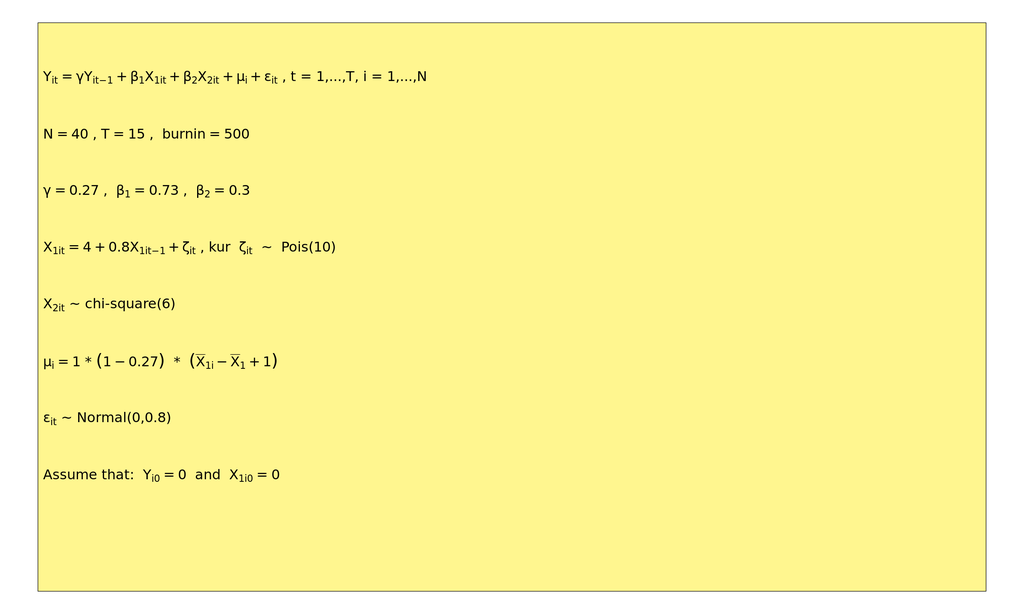

```r
url <- "http://web.vu.lt/mif/a.buteikis/wp-content/uploads/2023/09/Macro_2023_DPM.R"
source(url, encoding = "UTF-8")

STUDENT_CODE <- 2012527
genr_task(STUDENT_CODE)
```

Atsižvelgiant į nurodytas duomenų generavimo sąlygas, tai yra dinaminis panelinis modelis. Tą galima pastebėti iš to, jog yra įtrauktas priklausomas 'lag' kintamasis $Y_{it - 1}$ kaip vienas iš prediktorių. Pastarasis narys atspindi priklausomo kintamojo $Y$ reikšmę tam pačiam individui $i$ ankstensiu laikotarpiu $t - 1$.

Paprastumo dėlei tariama, jog nestebimi indvidų efektai $\mu_i$ nekoreliuoja su aiškinančiaisiais kintamaisiais $X_j$.

# I dalis: duomenų simuliacija

1. Parašykite funkciją gener_panel_data(), kuri sugeneruotų kintamuosius pagal nurodytas sąlygas:

```r
gener_panel_data <- function() {
  N <- 40
  T <- 15
  burnin <- 500
  n <- T + burnin # stebiniai
  gamma <- 0.27
  beta_1 <- 0.73
  beta_2 <- 0.3
  zeta <- matrix(rpois(N * n, lambda = 10), nrow = n)
  eps <- matrix(rnorm(N * n, mean = 0, sd = 0.8), nrow = n)

  Y <- eps
  X_1 <- eps
  X_2 <- matrix(rchisq(N * n, df = 6), nrow = n)
  mu <- 1 * (1 - 0.27) * (mean(X_1[1, ]) - mean(X_1) + 1)

  for (i in 2:n) {
    X_1[i, ] <- 4 + 0.8 * X_1[i - 1, ] + zeta[i, ]
    mu[i] <- 1 * (1 - 0.27) * (mean(X_1[i, ]) - mean(X_1) + 1)
    Y[i, ] <- gamma * Y[i - 1, ] + beta_1 * X_1[i, ] + beta_2 * X_2[i, ] + mu[i] + eps[i, ]
  }

  Y <- Y[(burnin + 1):n, ]
  X_1 <- X_1[(burnin + 1):n, ]
  X_2 <- X_2[(burnin + 1):n, ]

  id <- rep(1:N, each = T)
  time <- rep((burnin + 1):n, N)

  df <- data.frame(cbind("time" = time,
                         "id" = id,
                         "Y" = as.vector(Y),
                         "X1" = as.vector(X_1),
                         "X2" = as.vector(X_2)))

  return(df)
}
```

2. Patikrinkite apsirašyta funkciją:

```r
# Sugeneruojami duomenys pagal studento kodą:

set.seed(STUDENT_CODE)
DT <- gener_panel_data()
```

```r
# Sugeneruojami duomenys pagal studento kodą:

set.seed(STUDENT_CODE)
DT1 <- gener_panel_data()
```

```r
# Sugeneruojami duomenys pagal kitokį kodą

set.seed(123)
DT2 <- gener_panel_data()
```

```r
# Palyginami masyvai - turi būti FALSE:

all.equal(DT1, DT2)
```

1. 'Component “Y”: Mean relative difference: 0.07805069'

2. 'Component “X1”: Mean relative difference: 0.08132404'

3. 'Component “X2”: Mean relative difference: 0.6127731'

```r
# Palyginami masyvai - turi būti TRUE:

all.equal(DT, DT1)
```

TRUE

```r
# Pašalinti nebereikalingus masyvus:

rm(DT1, DT2)
```

```r
head(DT, 5)
```

A data.frame: 5 × 5

|  | time <dbl> | id <dbl> | Y <dbl> | X1 <dbl> | X2 <dbl> |
| --- | --- | --- | --- | --- | --- |
| 1 | 501 | 1 | 85.83829 | 78.85453 | 6.191965 |
| 2 | 502 | 1 | 83.17133 | 76.08363 | 5.596341 |
| 3 | 503 | 1 | 81.03342 | 72.86690 | 9.833843 |
| 4 | 504 | 1 | 84.74378 | 82.29352 | 2.699779 |
| 5 | 505 | 1 | 86.28808 | 79.83482 | 9.504039 |

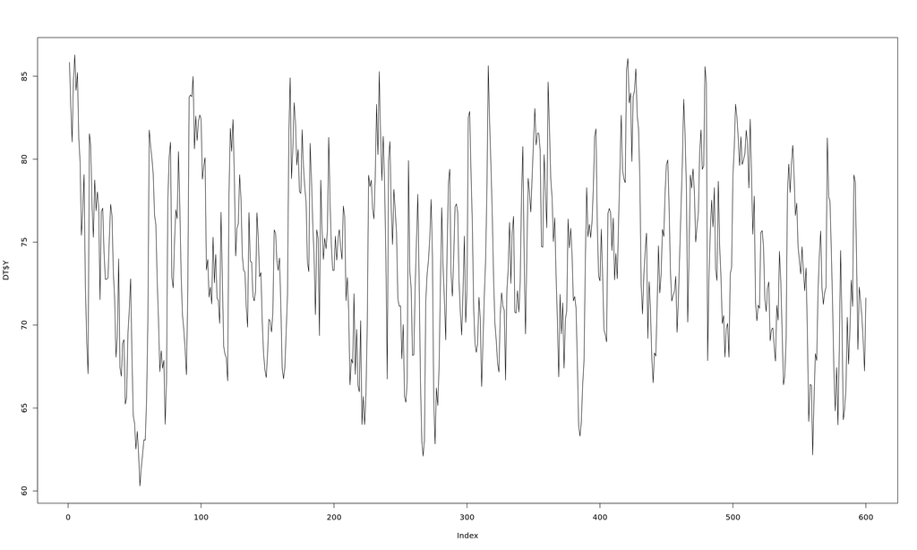

```r
# Tikrinimas, ar sugeneruotos 'Y_i' reikšmės nedidėja eksponentiškai:

plot(DT$Y, type = "l")
```

# II dalis: sugeneruotų duomenų analizė

3. Tarkime, kad iš pradžių nagrinėjame statinį panelinį modelį, bet:  
   (a) Nežinome, ar reikšmingi individų efektai, ar geriau sudaryti apjungtų duomenų regresiją (angl. pooled regression). Sudarykite atitinkamą modelį(-ius) ir patikrinkite ar yra reikšmingi individualūs efektai? (žr. pooltest);  
   (b) Nežinome, ar individų efektai koreliuoja su aiškinančiaisiais kintamaisiais. Sudarykite atitinkamą modelį(-ius) ir patikrinkite ar individualūs efektai koreliuoja su aiškinančiaisiais kintamaisiais? (žr. phtest);

```r
# (a):

pooled_model <- plm(Y ~ X1 + X2, data = DT, index = c("id", "time"), model = "pooling")
pvcm_model <- pvcm(Y ~ X1 + X2, data = DT, index = c("id", "time"), model = "within")
```

Tikrinama hipotezė naudojant $\verb|pooltest|$

\begin{cases} H_0: \text{Indvidualūs efektai nėra reikšmingi}\\ H_1: \text{Indvidualūs efektai yra reikšmingi} \end{cases}

```r
pooltest(pooled_model, pvcm_model)
```

```
	F statistic

data:  Y ~ X1 + X2
F = 1.2936, df1 = 117, df2 = 480, p-value = 0.03296
alternative hypothesis: unstability
```

```r
# (b)

model_fixed <- plm(Y ~ X1 + X2, data = DT, index = c("id", "time"), model = "within")
model_random <- plm(Y ~ X1 + X2, data = DT, index = c("id", "time"), model = "random")
```

Tikrinama hipotezė naudojant $\verb|phtest|$

\begin{cases} H_0: \text{Individų RE yra egzogeniniai}\\ H_1: \text{Individualūs RE nėra egzogeniniai} \end{cases}

```r
phtest(model_fixed, model_random)
```

```
	Hausman Test

data:  Y ~ X1 + X2
chisq = 13.311, df = 2, p-value = 0.001287
alternative hypothesis: one model is inconsistent
```

Kadangi $p-value$ < 0.05, tai turime pagrindą atmesti $H_0$. Dėl šios priežąsties teigiama, jog $FE$ yra efektyvesni nei $RE$.

4. Remdamiesi 3 užduoties rezultatais atsakykite - kuris statinis panelinis modelis geriausiai nusako jūsų duomenis? Patikrinkite, ar šio modelio liekanos autokoreliuotos. (žr. pbgtest, pwartest ir pan. testus plm pakete).

Turint omenyje 3 užduoties rezultatus, $FE$ modelis geriausiai nusako sugeneruotus duomenis.

Tikrinama hipotezė ar $FE$ modelio liekanos yra autokoreliuotos naudojant $\verb|pwartest|$

\begin{cases} H_0: \text{Modelio liekanos ne autokoreliuotos}\\ H_1: \text{Modelio liekanos autokoreliuotos} \end{cases}

```r
# Modelio liekanu autokoreliacijos testas:

pwartest(model_fixed)
```

```
	Wooldridge's test for serial correlation in FE panels

data:  model_fixed
F = 362, df1 = 1, df2 = 558, p-value < 2.2e-16
alternative hypothesis: serial correlation
```

Kadangi $p-value$ < 0.05, tai turime pagrindą atmesti $H_0$. Teigiama, jog $FE$ modelio liekanos yra autokoreliuotos. Dėl šios priežąsties reikia pasinaudoti kitais testais, kurie yra skirti patvirtinti, jog autokoreliacija iš tiesų egzistuoja sugeneruotose duomenyse.

5. Tarkime, kad norime patikrinti, ar nagrinėjamų panelinių duomenų laiko eilutės pasižymi priklausomybe laike:  
   (a) Pasižiūrėkite kiekvieno individo laiko eilutes - ar jos autokoreliuotos? (Galite naudoti, pvz. Ljung-Box, arba Box-Pierce testus);  
   (b) Patikrinkite, ar $Y_{it}$ turi vienetinę šaknį. (žr. purtest).

```r
# (a)

by(DT$Y, DT$id, function(i) { Box.test(i, lag = 1, type = "Ljung-Box") })
```

```
DT$id: 1

	Box-Ljung test

data:  i
X-squared = 8.5427, df = 1, p-value = 0.003469

------------------------------------------------------------
DT$id: 2

	Box-Ljung test

data:  i
X-squared = 3.2618, df = 1, p-value = 0.07091

------------------------------------------------------------
DT$id: 3

	Box-Ljung test

data:  i
X-squared = 7.318, df = 1, p-value = 0.006827

------------------------------------------------------------
DT$id: 4

	Box-Ljung test

data:  i
X-squared = 7.5106, df = 1, p-value = 0.006134

------------------------------------------------------------
DT$id: 5

	Box-Ljung test

data:  i
X-squared = 9.7356, df = 1, p-value = 0.001807

------------------------------------------------------------
```

[output cut: 263 more lines]

```
------------------------------------------------------------
DT$id: 39

	Box-Ljung test

data:  i
X-squared = 7.2306, df = 1, p-value = 0.007167

------------------------------------------------------------
DT$id: 40

	Box-Ljung test

data:  i
X-squared = 3.9948, df = 1, p-value = 0.04564
```

$lag = 1$ renkamasi dėl to, nes sąlygoje duotame modelyje $Y$ yra apibrėžtas kaip $Y_{it - 1}$. Tai indikuoja, jog naudojama vienu laiko momentu ankstesnė reikšmė ($lag 1$).\

Rezultatuose matome, jog daugumos individų $p-value$ < 0.05. Tai indikuoja, jog jų laiko eilutės yra autokoreliuotos. Vos keletos individų $p-value$ > 0.05 (tai reiškia, jog jų laiko eil. nėra autokoreliuotos).

```r
# (b)

y <- data.frame(split(DT$Y, DT$id))

purtest(y, pmax = 1, exo = "intercept", test = "madwu")
```

```
	Maddala-Wu Unit-Root Test (ex. var.: Individual Intercepts)

data:  y
chisq = 149.99, df = 80, p-value = 3.576e-06
alternative hypothesis: stationarity
```

Vienetinės šaknies testas naudojant $\verb|purtest|$

\begin{cases} H_0: \text{Vienetinė šaknis $\exists$}\\ H_1: \text{Vienetinė šaknis $\nexists$} \end{cases}

Kadangi $p-value$ < 0.05, tai turime pagrindą atmesti H_0. Teigiama, jog vienetinė šaknis neegzistuoja (stacionarumas). Tai reiškia, jog sugeneruoti duomenys neturi laiko trendo ir dispersija išlieka tokia pati bėgant laikui. Tai yra svarbu, nes daugelis statistinių metodų reikalauja stacionarumo.

6. Įvertinkite dinaminę panelinę regresiją:  
   (a) Panaudokite $Y_{i, t − 2}$ kaip instrumentą. (žr. pgmm ir mtest);  
   (b) Panaudokite daugiau instrumentų, pvz. Yi,t−1, ..., Yi,T −2. Ar įvertintų koeficientų įverčiai skiriasi nuo praeito punkto rezultatų, kai buvo naudojamas tik vienas instrumentas? (žr. pgmm ir mtest).

```r
# (a)

dynamic_pdm1 <- pgmm(Y ~ lag(Y, k = 1) + X1 + X2 | lag(Y, k = 2), data = DT, index = c("id", "time"),
                    effect = "individual", model = "twosteps")
summary(dynamic_pdm1)
```

```
Oneway (individual) effect Two-steps model Difference GMM

Call:
pgmm(formula = Y ~ lag(Y, k = 1) + X1 + X2 | lag(Y, k = 2), data = DT,
    effect = "individual", model = "twosteps", index = c("id",
        "time"))

Balanced Panel: n = 40, T = 15, N = 600

Number of Observations Used: 520
Residuals:
     Min.   1st Qu.    Median      Mean   3rd Qu.      Max.
-4.557659 -0.957716 -0.012986 -0.008603  0.898639  4.907692

Coefficients:
              Estimate Std. Error z-value  Pr(>|z|)
lag(Y, k = 1) 0.582357   0.071967   8.092  5.87e-16 ***
X1            0.758869   0.034633  21.912 < 2.2e-16 ***
X2            0.338040   0.026156  12.924 < 2.2e-16 ***
---
Signif. codes:  0 ‘***’ 0.001 ‘**’ 0.01 ‘*’ 0.05 ‘.’ 0.1 ‘ ’ 1

Sargan test: chisq(12) = 24.95747 (p-value = 0.015026)
Autocorrelation test (1): normal = -4.248745 (p-value = 2.1497e-05)
Autocorrelation test (2): normal = -0.9616133 (p-value = 0.33624)
Wald test for coefficients: chisq(3) = 544.0769 (p-value = < 2.22e-16)
```

Iš modelio rezultatų matoma, jog visi kintamieji yra stat. reikšm., kadangi atitinkamos $p-value$ < 0.05.

Tikrinimas, ar sudaryto dinaminio panelinio regresijos modelio liekanos yra autokoreliuotos. Pirmiausia, tikriname $AR(1)$. \

\begin{cases} H_0: \text{AR(1) $\nexists$}\\ H_1: \text{AR(1) $\exists$} \end{cases}

```r
mtest(dynamic_pdm1, order = 1)
```

```
	Arellano-Bond autocorrelation test of degree 1

data:  Y ~ lag(Y, k = 1) + X1 + X2 | lag(Y, k = 2)
normal = -4.3638, p-value = 1.278e-05
alternative hypothesis: autocorrelation present
```

Kadangi $p-value$ < 0.05, tai turime pagrindą atmesti $H_0$. Teigiama, jog sudarytame modelyje AR(1) egzistuoja.

Tikriname $AR(2)$:

\begin{cases} H_0: \text{AR(2) $\nexists$}\\ H_1: \text{AR(2) $\exists$} \end{cases}

```r
mtest(dynamic_pdm1, order = 2)
```

```
	Arellano-Bond autocorrelation test of degree 2

data:  Y ~ lag(Y, k = 1) + X1 + X2 | lag(Y, k = 2)
normal = -0.96281, p-value = 0.3356
alternative hypothesis: autocorrelation present
```

Kadangi p-value > 0.05, tai neturime pagrindo atmesti H_0. Teigiama, jog sudarytame modelyje AR(2) neegzistuoja. \

Literatūroje pabrėžiama, jog dažnu atveju $AR(1)$ testo rezultatas yra ignoruojamas, kadangi jo svarba ne itin didelė. Naudojant $GMM Estimation$ paneliniams duomenims yra tikėtina, jog $AR(1)$ egzistuos. Dėl šios priežasties yra atliekamas $AR(2)$ testas. Jei pastarojo $p-value$ > 0.05, tai toks rezultatas indikuoja, jog sudarytas modelis neturi problemų su autokoreliacija po 1-ojo $lag$.

```r
# (b)

dynamic_pdm2 <- pgmm(Y ~ lag(Y, 1) + X1 + X2 | lag(Y, k = 2:5), data = DT, index = c("id", "time"),
                    effect = "individual", model = "twosteps")
dynamic_pdm3 <- pgmm(Y ~ lag(Y, 1) + X1 + X2 | lag(Y, k = 5:10), data = DT, index = c("id", "time"),
                     effect = "individual", model = "twosteps")
dynamic_pdm4 <- pgmm(Y ~ lag(Y, 1) + X1 + X2 | lag(Y, k = 10:20), data = DT, index = c("id", "time"),
                     effect = "individual", model = "twosteps")
```

Modelių analizė:

```r
summary(dynamic_pdm2)
```

```
Oneway (individual) effect Two-steps model Difference GMM

Call:
pgmm(formula = Y ~ lag(Y, 1) + X1 + X2 | lag(Y, k = 2:5), data = DT,
    effect = "individual", model = "twosteps", index = c("id",
        "time"))

Balanced Panel: n = 40, T = 15, N = 600

Number of Observations Used: 520
Residuals:
    Min.  1st Qu.   Median     Mean  3rd Qu.     Max.
-4.36666 -0.93119 -0.02456 -0.02358  0.84430  4.67609

Coefficients:
          Estimate Std. Error z-value  Pr(>|z|)
lag(Y, 1) 0.548419   0.063254  8.6702 < 2.2e-16 ***
X1        0.751099   0.022963 32.7089 < 2.2e-16 ***
X2        0.333818   0.021672 15.4032 < 2.2e-16 ***
---
Signif. codes:  0 ‘***’ 0.001 ‘**’ 0.01 ‘*’ 0.05 ‘.’ 0.1 ‘ ’ 1

Sargan test: chisq(45) = 38.50405 (p-value = 0.74201)
Autocorrelation test (1): normal = -4.251696 (p-value = 2.1216e-05)
Autocorrelation test (2): normal = -0.9035061 (p-value = 0.36626)
Wald test for coefficients: chisq(3) = 1149.918 (p-value = < 2.22e-16)
```

```r
summary(dynamic_pdm3)
```

```
Oneway (individual) effect Two-steps model Difference GMM

Call:
pgmm(formula = Y ~ lag(Y, 1) + X1 + X2 | lag(Y, k = 5:10), data = DT,
    effect = "individual", model = "twosteps", index = c("id",
        "time"))

Balanced Panel: n = 40, T = 15, N = 600

Number of Observations Used: 400
Residuals:
    Min.  1st Qu.   Median     Mean  3rd Qu.     Max.
-3.23674 -0.87338 -0.07062 -0.02748  0.85467  4.02236

Coefficients:
          Estimate Std. Error z-value  Pr(>|z|)
lag(Y, 1) 0.419904   0.049319  8.5141 < 2.2e-16 ***
X1        0.731847   0.024527 29.8383 < 2.2e-16 ***
X2        0.328513   0.021429 15.3304 < 2.2e-16 ***
---
Signif. codes:  0 ‘***’ 0.001 ‘**’ 0.01 ‘*’ 0.05 ‘.’ 0.1 ‘ ’ 1

Sargan test: chisq(44) = 39.22799 (p-value = 0.676)
Autocorrelation test (1): normal = -4.342169 (p-value = 1.4108e-05)
Autocorrelation test (2): normal = 0.05135217 (p-value = 0.95904)
Wald test for coefficients: chisq(3) = 983.1942 (p-value = < 2.22e-16)
```

```r
summary(dynamic_pdm4)
```

```
Oneway (individual) effect Two-steps model Difference GMM

Call:
pgmm(formula = Y ~ lag(Y, 1) + X1 + X2 | lag(Y, k = 10:20), data = DT,
    effect = "individual", model = "twosteps", index = c("id",
        "time"))

Balanced Panel: n = 40, T = 15, N = 600

Number of Observations Used: 200
Residuals:
    Min.  1st Qu.   Median     Mean  3rd Qu.     Max.
-2.99922 -0.93329 -0.07095 -0.03003  0.79368  3.75056

Coefficients:
          Estimate Std. Error z-value  Pr(>|z|)
lag(Y, 1) 0.405820   0.066669  6.0871  1.15e-09 ***
X1        0.725935   0.041141 17.6452 < 2.2e-16 ***
X2        0.297562   0.033728  8.8225 < 2.2e-16 ***
---
Signif. codes:  0 ‘***’ 0.001 ‘**’ 0.01 ‘*’ 0.05 ‘.’ 0.1 ‘ ’ 1

Sargan test: chisq(14) = 28.14843 (p-value = 0.013596)
Autocorrelation test (1): normal = -4.298972 (p-value = 1.7159e-05)
Autocorrelation test (2): normal = -1.096616 (p-value = 0.27281)
Wald test for coefficients: chisq(3) = 382.7428 (p-value = < 2.22e-16)
```

Į modelius įtraukiant daugiau instrumentų (didinat Y kint. 'lag' skaičių), modelio kintamieji visais atvejais išlieka stat. reikšm., kadangi atitinkamos jų $p-value$ < 0.05. Taip pat, visais keturiais atvejais modelių kintamųjų įverčiai yra gana panašūs. Labiausiai pastebimas skirtumas lyginant 3-iąjį bei 4-ąjį modelį su pirmais dvejais yra tas, jog $lag(Y, k = 1)$ kint. įvertis skiriasi per 0,1. Tai yra didžiausias pastebimas skirtumas lyginant modelių kint. įverčius tarpusavyje.

Sudarytų modelių $AR(1)$ ir $AR(2)$ testai:

```r
mtest(dynamic_pdm2, order = 1)
mtest(dynamic_pdm2, order = 2)
```

```
	Arellano-Bond autocorrelation test of degree 1

data:  Y ~ lag(Y, 1) + X1 + X2 | lag(Y, k = 2:5)
normal = -4.4124, p-value = 1.022e-05
alternative hypothesis: autocorrelation present
```

```
	Arellano-Bond autocorrelation test of degree 2

data:  Y ~ lag(Y, 1) + X1 + X2 | lag(Y, k = 2:5)
normal = -0.90443, p-value = 0.3658
alternative hypothesis: autocorrelation present
```

```r
mtest(dynamic_pdm3, order = 1)
mtest(dynamic_pdm3, order = 2)
```

```
	Arellano-Bond autocorrelation test of degree 1

data:  Y ~ lag(Y, 1) + X1 + X2 | lag(Y, k = 5:10)
normal = -4.4647, p-value = 8.019e-06
alternative hypothesis: autocorrelation present
```

```
	Arellano-Bond autocorrelation test of degree 2

data:  Y ~ lag(Y, 1) + X1 + X2 | lag(Y, k = 5:10)
normal = 0.051602, p-value = 0.9588
alternative hypothesis: autocorrelation present
```

```r
mtest(dynamic_pdm4, order = 1)
mtest(dynamic_pdm4, order = 2)
```

```
	Arellano-Bond autocorrelation test of degree 1

data:  Y ~ lag(Y, 1) + X1 + X2 | lag(Y, k = 10:20)
normal = -4.4783, p-value = 7.524e-06
alternative hypothesis: autocorrelation present
```

```
	Arellano-Bond autocorrelation test of degree 2

data:  Y ~ lag(Y, 1) + X1 + X2 | lag(Y, k = 10:20)
normal = -1.1604, p-value = 0.2459
alternative hypothesis: autocorrelation present
```

Atliktus testus naujai sudarytiems modeliams, pastebima ta pati tendencija kaip ir $dynamic_pdm1$ atveju. $AR(1)$ egzistuoja visuos modeliuos, tačiau $AR(2)$ nei viename iš jų nėra. Pastebima, jog rezultatai išliko tokie patys padidinus instrumetų kiekį.

7. Ką galima pasakyti apie koeficientų įverčius, jeigu vietoje dinaminio panelinio modelio (kuris yra tikrasis DGP) nuspręstume įvertinti statinį panelinį modelį? Susikurkite naują stulpelį pavadinimu $Y_lag$ su $Y_{i, t − 1}$ reikšmėmis. Įvertinkite 6 užduoties regresiją naudodami $POLS$, $RE$ ir $FE (within)$ vertinimo metodus (žr. plm funkciją). Atspausdinkite modelių rezultatus su stargazer paketu ([render in RMarkdown 1] and [render in RMarkdown 2], [render in JupyterLab], bei [komentarą dėl pgmm objektų]).

Esminis skirtumas tarp statinio ir dinaminio panelinio modelio yra tai, jog dinaminis modelis atsižvelgia įlaiko kitimą. Kitaip tariant, vertinant tokį modelį atsižvelgiama į praeities duomenis. Jei būtų nuspręsta įvertinti statinį panelinį modelį, kai tikrasis yra dinaminis, koeficientų įverčiai nebūtų tokie tikslūs vien dėl to, jog nėra atsižvelgiama į praeities tendencijas.

```r
DT$Y_lag <- c(NA, head(DT$Y, -1))
```

```r
head(DT, 5)
```

A data.frame: 5 × 6

|  | time <dbl> | id <dbl> | Y <dbl> | X1 <dbl> | X2 <dbl> | Y_lag <dbl> |
| --- | --- | --- | --- | --- | --- | --- |
| 1 | 501 | 1 | 85.83829 | 78.85453 | 6.191965 | NA |
| 2 | 502 | 1 | 83.17133 | 76.08363 | 5.596341 | 85.83829 |
| 3 | 503 | 1 | 81.03342 | 72.86690 | 9.833843 | 83.17133 |
| 4 | 504 | 1 | 84.74378 | 82.29352 | 2.699779 | 81.03342 |
| 5 | 505 | 1 | 86.28808 | 79.83482 | 9.504039 | 84.74378 |

```r
# Modeliai:

POLS_model <- plm(Y ~ Y_lag + X1 + X2, data = DT, index = c("id", "time"), model = "pooling")
RE_model <- plm(Y ~ Y_lag + X1 + X2, data = DT, index = c("id", "time"), model = "random")
FE_model <- plm(Y ~ Y_lag + X1 + X2, data = DT, index = c("id", "time"), model = "within")
```

```r
stargazer(list(POLS_model, RE_model, FE_model), type = "text", column.labels = c("POLS", "RE", "FE"))
```

```
================================================================================
                                     Dependent variable:
             -------------------------------------------------------------------
                                              Y
                        POLS                 RE                   FE
                        (1)                  (2)                 (3)
--------------------------------------------------------------------------------
Y_lag                 0.272***            0.272***             0.283***
                      (0.013)              (0.013)             (0.015)

X1                    0.756***            0.756***             0.772***
                      (0.014)              (0.014)             (0.016)

X2                    0.304***            0.304***             0.308***
                      (0.015)              (0.015)             (0.016)

Constant               -0.437              -0.437
                      (0.767)              (0.767)

--------------------------------------------------------------------------------
Observations            599                  599                 599
R2                     0.944                0.944               0.903
Adjusted R2            0.944                0.944               0.896
F Statistic  3,368.780*** (df = 3; 595) 10,106.340*** 1,730.485*** (df = 3; 556)
================================================================================
Note:                                                *p<0.1; **p<0.05; ***p<0.01
```

```r
stargazer(list(dynamic_pdm1, dynamic_pdm2, dynamic_pdm3, dynamic_pdm4), type = "text", column.labels = c("Lag 1", "Lag 2:5", "Lag 5:10", "Lag 10:20"))
```

```
==================================================
                      Dependent variable:
              ------------------------------------
                               Y
               Lag 1   Lag 2:5  Lag 5:10 Lag 10:20
                (1)      (2)      (3)       (4)
--------------------------------------------------
lag(Y, k = 1) 0.582***
              (0.072)

lag(Y, 1)              0.548*** 0.420*** 0.406***
                       (0.063)  (0.049)   (0.067)

X1            0.759*** 0.751*** 0.732*** 0.726***
              (0.035)  (0.023)  (0.025)   (0.041)

X2            0.338*** 0.334*** 0.329*** 0.298***
              (0.026)  (0.022)  (0.021)   (0.034)

--------------------------------------------------
Observations     40       40       40       40
==================================================
Note:                  *p<0.1; **p<0.05; ***p<0.01
```

# III dalis: Monte Carlo simuliacija

8. Atlikite Monte Carlo (MC) simuliaciją su M = 3000 replikacijų. Prieš pradėdami nurodykite set.seed(STUDENT_CODE). Tuomet kiekvienam m = 1, ..., M:  
   (a) Sugeneruokite duomenis pasinaudoję savo sukurta genr_panel_data() funkcija (sugeneruoti duomenys turi skirtis kiekvienam m);  
   (b) Susikurkite naują kintamąjį (stulpelį) $Y_{i, t − 1}$;  
   (c) Sudarykite modelį $Y_{i, t} = \gamma Y_{i, t − 1} + \beta_1X_{1, i, t} + \beta_2X_{2, i, t} + \eta_{i, t}$ ir:
- įvertinkite modelio parametrus POLS metodu\
- įvertinkite FE (within) modelį \
- įvertinkite RE modelį \
- įvertinkite dinaminį panelinį modelį (žr. 6 užduotį)

```r
set.seed(STUDENT_CODE)

# Sukuriami 'list' kiekvienam iš modelio 'gamma', 'beta_1' ir 'beta_2' koeficientams saugoti

POLS_gamma <- list()
POLS_beta_1 <- list()
POLS_beta_2 <- list()

FE_gamma <- list()
FE_beta_1 <- list()
FE_beta_2 <- list()

RE_gamma <- list()
RE_beta_1 <- list()
RE_beta_2 <- list()

DYN_pdata_gamma <- list()
DYN_pdata_beta_1 <- list()
DYN_pdata_beta_2 <- list()

M <- 3000

model <- Y ~ lag(Y, 1) + X1 + X2

time_start <- Sys.time()

for (m in 1:M) {
  DT <- gener_panel_data()
  DT$Y_lag <- c(NA, head(DT$Y, -1))

  POLS_model <- plm(Y ~ Y_lag + X1 + X2, data = DT, index = c("id", "time"), model = "pooling")
  POLS_gamma <- c(POLS_gamma, as.numeric(POLS_model$coefficients[2]))
  POLS_beta_1 <- c(POLS_beta_1, as.numeric(POLS_model$coefficients[3]))
  POLS_beta_2 <- c(POLS_beta_2, as.numeric(POLS_model$coefficients[4]))

  RE_model <- plm(Y ~ Y_lag + X1 + X2, data = DT, index = c("id", "time"), model = "random")
  RE_gamma <- c(RE_gamma, as.numeric(RE_model$coefficients[2]))
  RE_beta_1 <- c(RE_beta_1, as.numeric(RE_model$coefficients[3]))
  RE_beta_2 <- c(RE_beta_2, as.numeric(RE_model$coefficients[4]))

  FE_model <- plm(Y ~ Y_lag + X1 + X2, data = DT, index = c("id", "time"), model = "within")
  FE_gamma <- c(FE_gamma, as.numeric(FE_model$coefficients[1]))
  FE_beta_1 <- c(FE_beta_1, as.numeric(FE_model$coefficients[2]))
  FE_beta_2 <- c(FE_beta_2, as.numeric(FE_model$coefficients[3]))

  DYN_pdm <- pgmm(Y ~ lag(Y, 1) + X1 + X2 | lag(Y, 2), data = DT, index = c("id", "time"), effect = "individual", model = "twosteps")
  DYN_pdata_gamma <- c(DYN_pdata_gamma, as.numeric(DYN_pdm$coefficients[[2]][1]))
  DYN_pdata_beta_1 <- c(DYN_pdata_beta_1, as.numeric(DYN_pdm$coefficients[[2]][2]))
  DYN_pdata_beta_2 <- c(DYN_pdata_beta_2, as.numeric(DYN_pdm$coefficients[[2]][3]))
}

time_end <- Sys.time()
print(time_end - time_start)
```

[output not shown]

Kadangi 'DYN_pdm' ateju buvo pasirinkta naudoti 'twosteps' modelį, tai dėl šios priežasties modelio koeficientai yra įvertinami du kartus. Literatūroje teigiama, jog antruoju kartu įvertinti koeficientai yra tikslesni. Dėl to, saugant modelio 'gamma', 'beta_1' bei 'beta_2' koeficientų įverčius, buvo pasirinkta naudoti tuos, kurie buvo įvertinti antrąjį kartą.

9. Kiekvienam parametrų vertinimo metodui (POLS, FE, RE ir AB) išsibrėžkite dviejų tipų grafikus:

(a) Histogramos (geom_histogram()) gautiems hat_gamma, hat_beta_1 ir hat_beta_2 įverčiams. Grafikuose pažymėkite atitinkamų parametrų tikrąsias reikšmes (pvz., vertikaliomis linijomis, geom_vline()). Gali būti patogu naudoti [patchwork bibioteką]; (b) Kiekvienam vertinimo metodui išbrėžkite poslinkių (gamma − hat_gamma, beta_1 − hat_beta_1 ir beta_2 − hat_beta_2) tankio (geom_density()) grafikus.

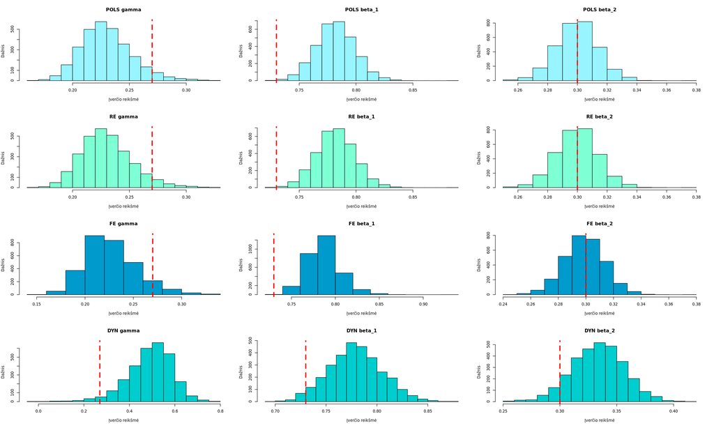

```r
# (a)

par(mfrow = c(4, 3))

hist(as.numeric(POLS_gamma), col = "cadetblue1", main = "POLS gamma", xlab = "Įverčio reikšmė", ylab = "Dažnis")
abline(v = 0.27, col="red", lwd = 3, lty = "dashed")
hist(as.numeric(POLS_beta_1), col = "cadetblue1", main = "POLS beta_1", xlab = "Įverčio reikšmė", ylab = "Dažnis")
abline(v = 0.73, col="red", lwd = 3, lty = "dashed")
hist(as.numeric(POLS_beta_2), col = "cadetblue1", main = "POLS beta_2", xlab = "Įverčio reikšmė", ylab = "Dažnis")
abline(v = 0.3, col="red", lwd = 3, lty = "dashed")

hist(as.numeric(RE_gamma), col = "aquamarine", main = "RE gamma", xlab = "Įverčio reikšmė", ylab = "Dažnis")
abline(v = 0.27, col="red", lwd = 3, lty = "dashed")
hist(as.numeric(RE_beta_1), col = "aquamarine", main = "RE beta_1", xlab = "Įverčio reikšmė", ylab = "Dažnis")
abline(v = 0.73, col="red", lwd = 3, lty = "dashed")
hist(as.numeric(RE_beta_2), col = "aquamarine", main = "RE beta_2", xlab = "Įverčio reikšmė", ylab = "Dažnis")
abline(v = 0.3, col="red", lwd = 3, lty = "dashed")

hist(as.numeric(FE_gamma), col = "deepskyblue3", main = "FE gamma", xlab = "Įverčio reikšmė", ylab = "Dažnis")
abline(v = 0.27, col="red", lwd = 3, lty = "dashed")
hist(as.numeric(FE_beta_1), col = "deepskyblue3", main = "FE beta_1", xlab = "Įverčio reikšmė", ylab = "Dažnis")
abline(v = 0.73, col="red", lwd = 3, lty = "dashed")
hist(as.numeric(FE_beta_2), col = "deepskyblue3", main = "FE beta_2", xlab = "Įverčio reikšmė", ylab = "Dažnis")
abline(v = 0.3, col="red", lwd = 3, lty = "dashed")

hist(as.numeric(DYN_pdata_gamma), col = "cyan3", main = "DYN gamma", xlab = "Įverčio reikšmė", ylab = "Dažnis")
abline(v = 0.27, col="red", lwd = 3, lty = "dashed")
hist(as.numeric(DYN_pdata_beta_1), col = "cyan3", main = "DYN beta_1", xlab = "Įverčio reikšmė", ylab = "Dažnis")
abline(v = 0.73, col="red", lwd = 3, lty = "dashed")
hist(as.numeric(DYN_pdata_beta_2), col = "cyan3", main = "DYN beta_2", xlab = "Įverčio reikšmė", ylab = "Dažnis")
abline(v = 0.3, col="red", lwd = 3, lty = "dashed")
```

Pastebime bendrą tendenciją grafikuose, visų įvertintų koeficientų reikšmės yra pasiskirsčiuosios pagal normalųjį skirstinį. Taip pat, praktiškai visos histogramos yra simetrinės apart kelių, kurios yra pasislinkusios į dešinę ('FE beta_1') arba į kairę ('DYN gamma'). Raudonos punktyrinės linijos šiuo atveju žymi tikrąsias parametrų reikšmes 'gamma', 'beta_1' ir 'beta_2', atitinkamai. Kaip matome, visi keturi modeliai tiksliausiai įvertino 'beta_2' reikšmes. Likusių kintamųjų rezultatai nėra itin geri.

10. Palyginkite skirtingus metodus su tikrosiomis parametrų reikšmėmis - kuris metodas tiksliausias ir ar to buvo galima tikėtis?

```r
# Tikrosios parametrų reikšmės:

gamma <- 0.27
beta_1 <- 0.73
beta_2 <- 0.3

# POLS modelio įverčių vidurkiai

POLS_g <- mean(as.numeric(POLS_gamma))
POLS_b1 <- mean(as.numeric(POLS_beta_1))
POLS_b2 <- mean(as.numeric(POLS_beta_2))

POLS_paklaida <- (POLS_g - gamma) + (POLS_b1 - beta_1) + (POLS_b2 - beta_2)

RE_g <- mean(as.numeric(RE_gamma))
RE_b1 <- mean(as.numeric(RE_beta_1))
RE_b2 <- mean(as.numeric(RE_beta_2))

RE_paklaida <- (RE_g - gamma) + (RE_b1 - beta_1) + (RE_b2 - beta_2)

FE_g <- mean(as.numeric(FE_gamma))
FE_b1 <- mean(as.numeric(FE_beta_1))
FE_b2 <- mean(as.numeric(FE_beta_2))

FE_paklaida <- (FE_g - gamma) + (FE_b1 - beta_1) + (FE_b2 - beta_2)

DYN_g <- mean(as.numeric(DYN_pdata_gamma))
DYN_b1 <- mean(as.numeric(DYN_pdata_beta_1))
DYN_b2 <- mean(as.numeric(DYN_pdata_beta_2))

DYN_paklaida <- (DYN_g - gamma) + (DYN_b1 - beta_1) + (DYN_b2 - beta_2)

paklaida <- c("POLS" = POLS_paklaida, "RE" = RE_paklaida, "FE" = FE_paklaida, "DYN" = DYN_paklaida)
paklaida
min(paklaida)
```

**POLS**

0.0117721148800975

**RE**

0.0117217593597254

**FE**

0.012086500777019

**DYN**

0.303049899636498

0.0117217593597254